# Moments of a Random Variable

2025

## Basic Definitions

- Sometimes specifying the entire probability distribution is cumbersome or unnecessary.
- Moments of a random variable are scalar values computed from the probability distribution.
- They provide insight into a probability distribution’s central tendency, dispersion, skewness, kurtosis, etc.

## Expected Value

- The expected value of a random variable is a measure of central tendency.
- It is the weighted average of the possible values, where the weights are the probabilities.

**Discrete Random Variables**

\[ \mathbb{E}(X)=\sum_{i=1}^n x_ip(x_i)=\mu_X \]

**Discrete Example:**

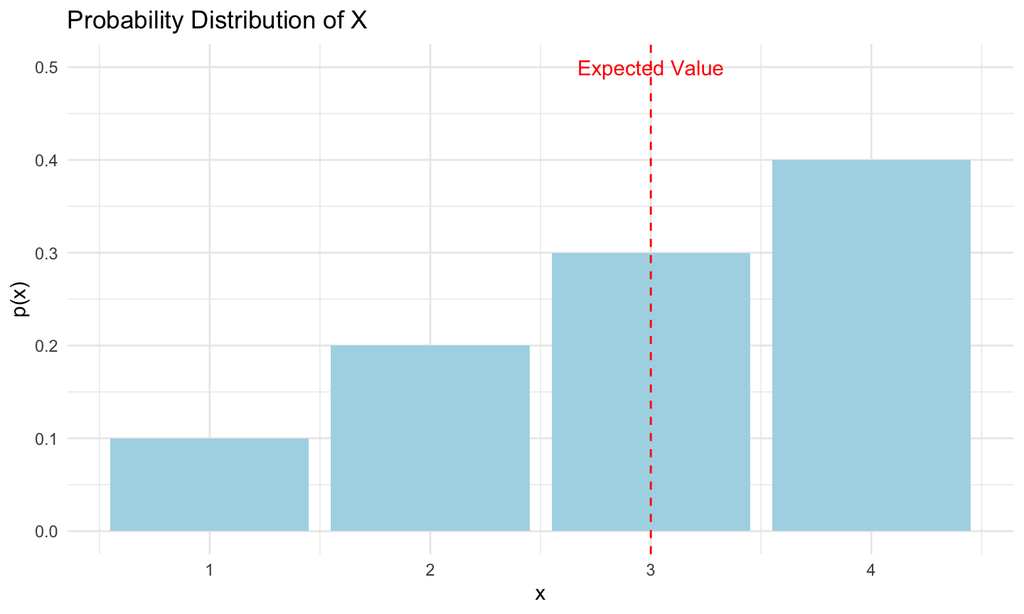

## Sampling from a Discrete Distribution

- The sample mean is an estimate of the population mean.

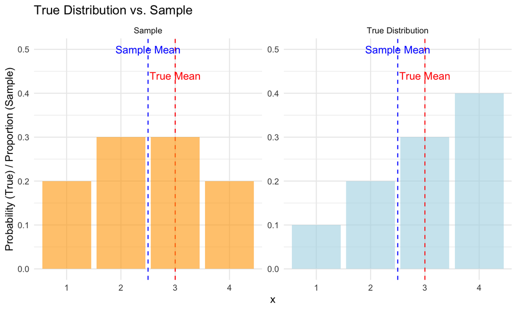

## Expected Value for a Continuous Distribution

\[ \mathbb{E}(X)=\int_{-\infty}^{\infty} x f(x)dx=\mu_X \]

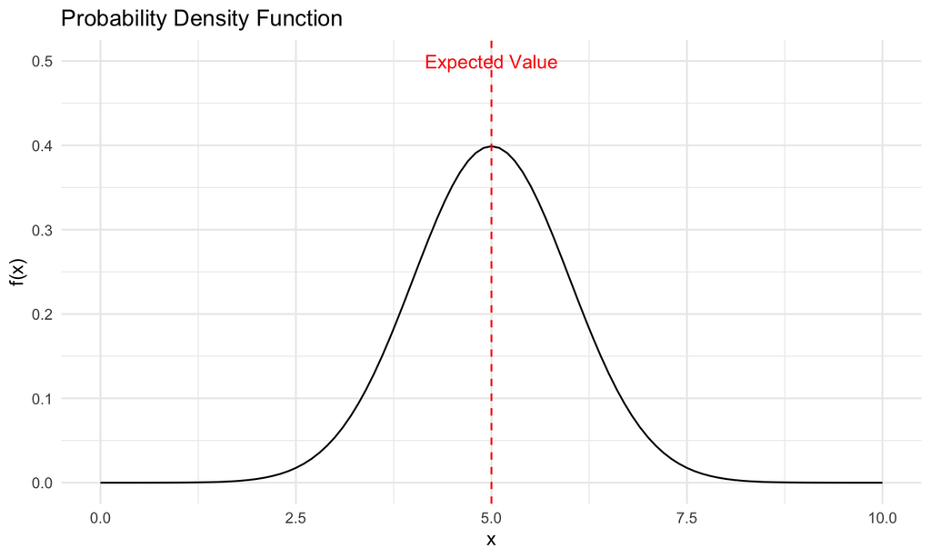

## Sampling from a Continuous Distribution

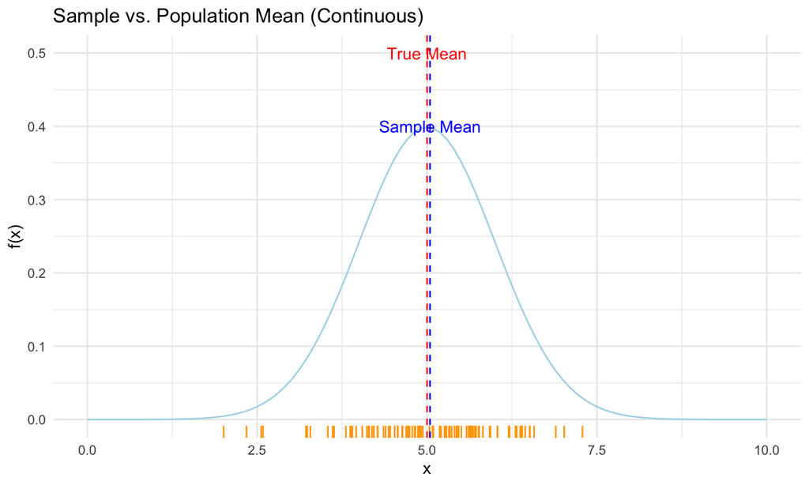

## Variance

- Variance measures dispersion:

### Discrete Random Variables

\[ \text{Var}(X)=\sum_{i=1}^n (x_i-\mu_X)^2 p(x_i)=\sigma_X^2 \]

## Sampling to Estimate Variance

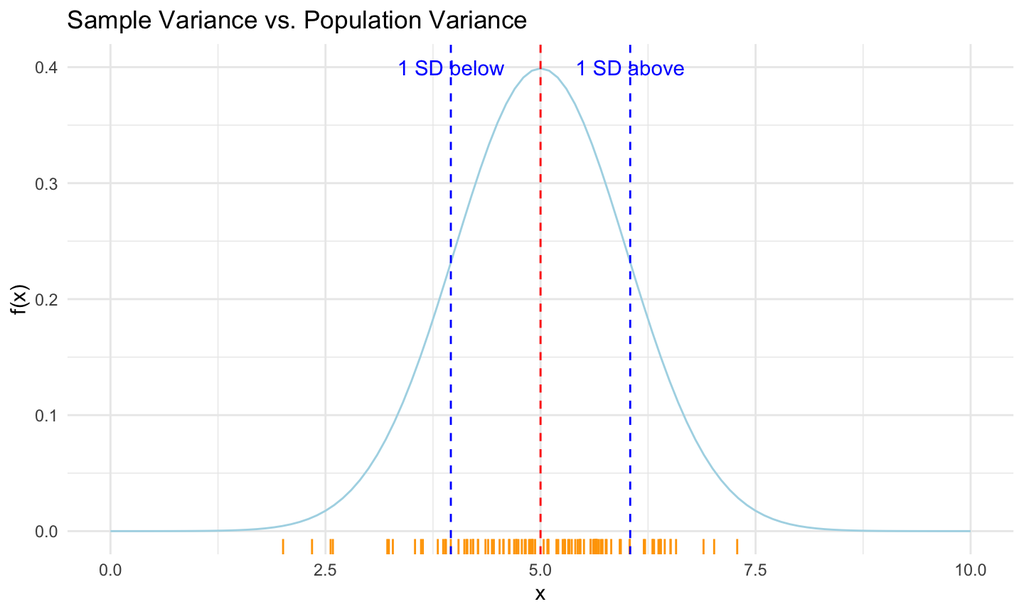

## Key Takeaways

- Sample statistics estimate population parameters.
- Bar graph, histogram, density plots etc are estimates of the probability distribution of a random variable.

## Quiz question

A discrete random variable \(X\) has the following probability mass function (PMF):

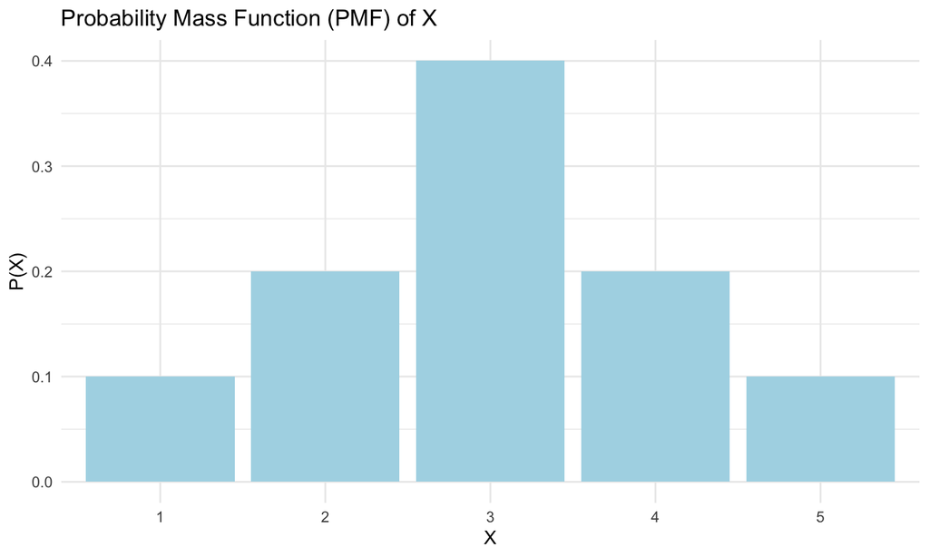

Looking at the PMF plot, which of the following statements is **most correct**?

**A.** The expected value \(\mathbb{E}(X)\) is likely close to 3 because the PMF is symmetric around 3.

**B.** The expected value \(\mathbb{E}(X)\) is closer to 2 because lower values of \(X\) have higher probabilities than higher values.

**C.** The variance \(\text{Var}(X)\) is larger than 100 because there is a wide spread of values in the PMF.

**D.** The variance \(\text{Var}(X)\) is smaller than 100 because most of the probability mass is concentrated near the center of the distribution.

**Click to see the solution**

**Correct Answer:** **A and D**

- **Expected Value (\(\mathbb{E}(X)\))** The PMF is **symmetric** around \(X = 3\), and most of the probability mass is centered there. This suggests that the expected value is around 3.
- **Variance (\(\text{Var}(X)\))**
  - **D is correct** because most of the probability is concentrated around \(X = 3\), meaning the values do not deviate far from the mean, resulting in a **small variance**.